# Case Study 1 - Final Report

Ikenna Nwaogu & Sterling Beason

10/26/2019

### Acronyms

**Alcohol Content = ABV**

**International Bitterness Units = IBU**

**K Nearest Neighbors = KNN**

## Question 1: Breweries Per State

**Below are the frequency of breweries per state. Colorado has the most at 47.**

| x | freq |
| --- | --- |
| AK | 7 |
| AL | 3 |
| AR | 2 |
| AZ | 11 |
| CA | 39 |
| CO | 47 |
| CT | 8 |
| DC | 1 |
| DE | 2 |
| FL | 15 |
| GA | 7 |
| HI | 4 |
| IA | 5 |
| ID | 5 |
| IL | 18 |
| IN | 22 |
| KS | 3 |
| KY | 4 |
| LA | 5 |
| MA | 23 |
| MD | 7 |
| ME | 9 |
| MI | 32 |
| MN | 12 |
| MO | 9 |
| MS | 2 |
| MT | 9 |
| NC | 19 |
| ND | 1 |
| NE | 5 |
| NH | 3 |
| NJ | 3 |
| NM | 4 |
| NV | 2 |
| NY | 16 |
| OH | 15 |
| OK | 6 |
| OR | 29 |
| PA | 25 |
| RI | 5 |
| SC | 4 |
| SD | 1 |
| TN | 3 |
| TX | 28 |
| UT | 4 |
| VA | 16 |
| VT | 10 |
| WA | 23 |
| WI | 20 |
| WV | 1 |
| WY | 4 |

## Question 2: Merge Beer and Breweries Data

### First and Last Six Observations

```
##   Brew_ID           brewName        City State      beerName Beer_ID   ABV
## 1       1 NorthGate Brewing  Minneapolis    MN  Get Together    2692 0.045
## 2       1 NorthGate Brewing  Minneapolis    MN Maggie's Leap    2691 0.049
## 3       1 NorthGate Brewing  Minneapolis    MN    Wall's End    2690 0.048
## 4       1 NorthGate Brewing  Minneapolis    MN       Pumpion    2689 0.060
## 5       1 NorthGate Brewing  Minneapolis    MN    Stronghold    2688 0.060
## 6       1 NorthGate Brewing  Minneapolis    MN   Parapet ESB    2687 0.056
##   IBU                               Style Ounces
## 1  50                        American IPA     16
## 2  26                  Milk / Sweet Stout     16
## 3  19                   English Brown Ale     16
## 4  38                         Pumpkin Ale     16
## 5  25                     American Porter     16
## 6  47 Extra Special / Strong Bitter (ESB)     16
```

```
##      Brew_ID                      brewName          City State
## 2405     556         Ukiah Brewing Company         Ukiah    CA
## 2406     557       Butternuts Beer and Ale Garrattsville    NY
## 2407     557       Butternuts Beer and Ale Garrattsville    NY
## 2408     557       Butternuts Beer and Ale Garrattsville    NY
## 2409     557       Butternuts Beer and Ale Garrattsville    NY
## 2410     558 Sleeping Lady Brewing Company     Anchorage    AK
##                       beerName Beer_ID   ABV IBU                   Style
## 2405             Pilsner Ukiah      98 0.055  NA         German Pilsener
## 2406  Heinnieweisse Weissebier      52 0.049  NA              Hefeweizen
## 2407           Snapperhead IPA      51 0.068  NA            American IPA
## 2408         Moo Thunder Stout      50 0.049  NA      Milk / Sweet Stout
## 2409         Porkslap Pale Ale      49 0.043  NA American Pale Ale (APA)
## 2410 Urban Wilderness Pale Ale      30 0.049  NA        English Pale Ale
##      Ounces
## 2405     12
## 2406     12
## 2407     12
## 2408     12
## 2409     12
## 2410     12
```

## Question 3: Missing Values in Each Column

**ABV and IBU both have missing values in the dataset. ABV and IBU have 62 and 1005 NA values respectively**

```
##  Brew_ID brewName     City    State beerName  Beer_ID      ABV      IBU
##        0        0        0        0        0        0       62     1005
##    Style   Ounces
##        0        0
```

## Question 4: Median ABV and IBU for Each State

**ABV has less variance than the IBU variable. Interestingly Maine has the highest median IBU**

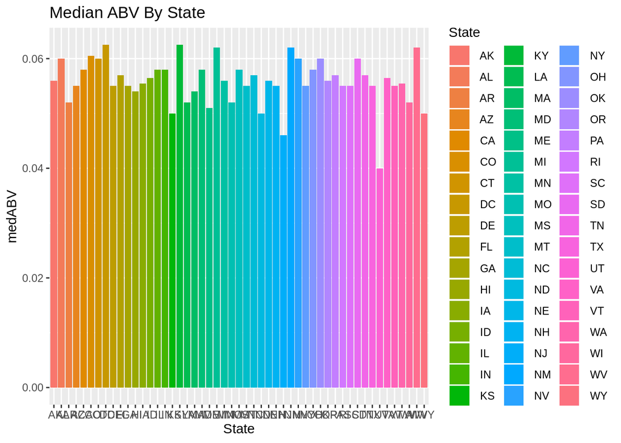

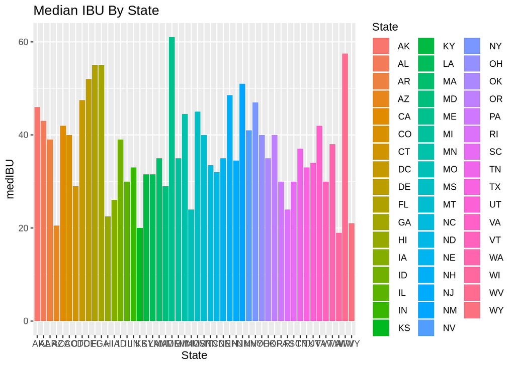

## Question 5: Highest ABV and IBU by State

**Colorado has the highest ABV and Oregon has the highest IBU.**

```
##   State   ABV
## 1    CO 0.128
```

```
##   State IBU
## 1    OR 138
```

### Maps For Questions 1, 4, 5

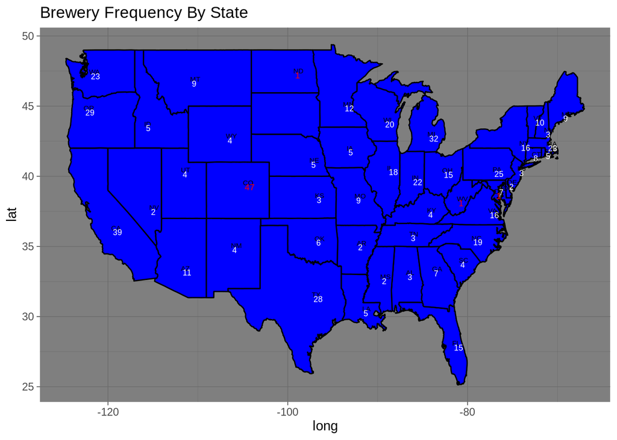

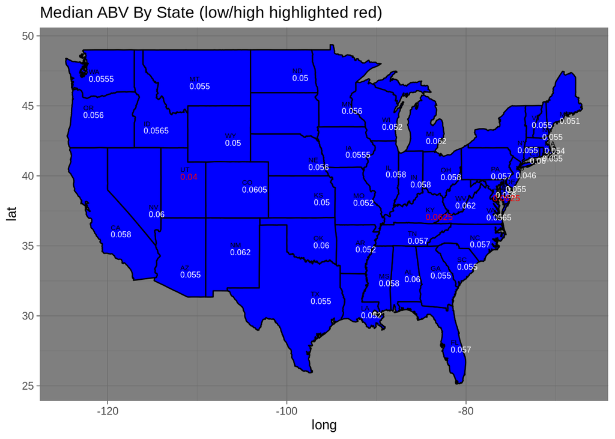

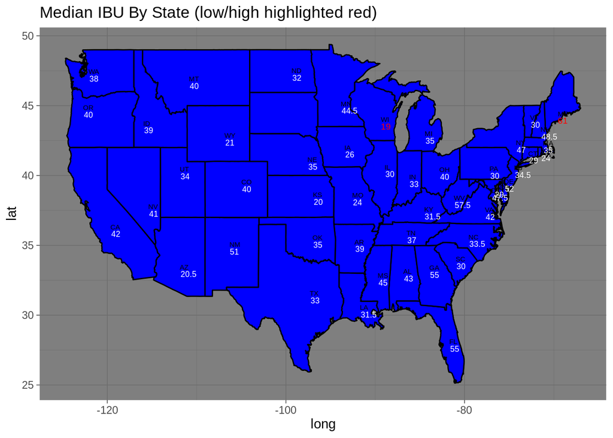

## Question 6: ABV Summary Statistics

**The distribution of ABV across beers is slightly right-skewed.**

**Most beers’ ABV are within 2.5% and 10%.**

**The median ABV is 5.6% and the mean is 5.98%.**

**The max ABV is 12.8%.**

```
##    Min. 1st Qu.  Median    Mean 3rd Qu.    Max.
## 0.00100 0.05000 0.05600 0.05977 0.06700 0.12800
```

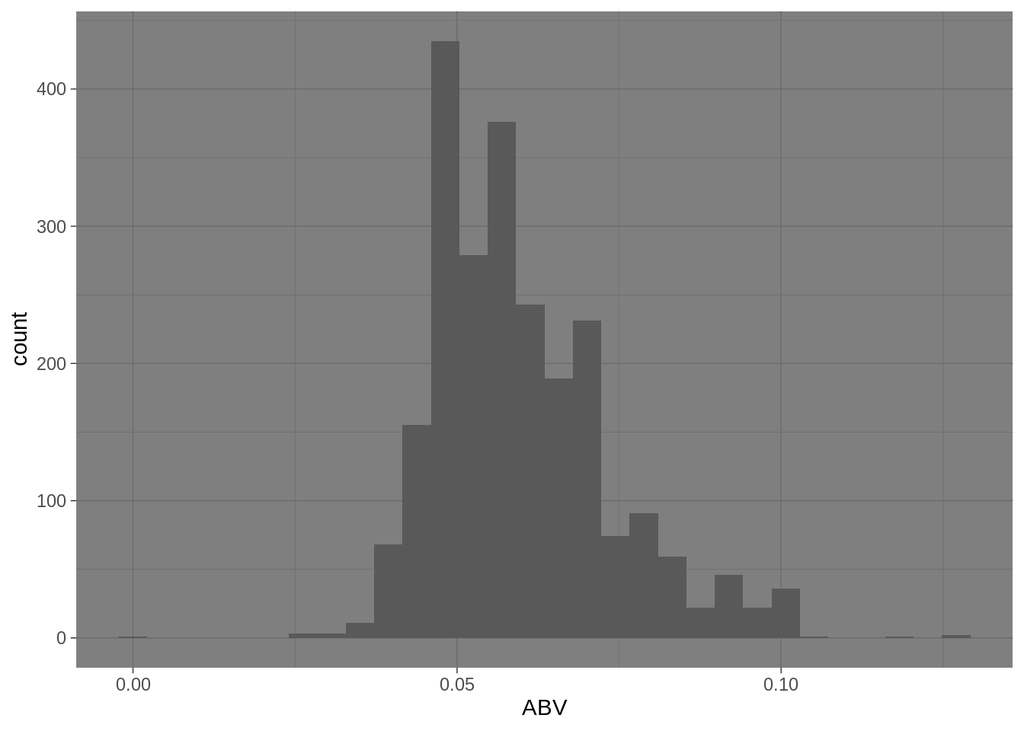

## Question 7: ABV vs IBU Scatterplot

**There is a positive relationship between alcohol content and the bitterness of a beer generally.**

**You can see the higher the ABV, the higher the IBU.**

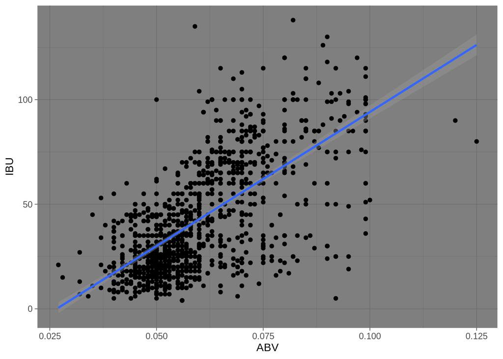

# Question 8: Style Predictions from ABV and IBU in KNN

```
## [1] Brew_ID Name    City    State
## <0 rows> (or 0-length row.names)
```

```
##  [1] "Brew_ID" "Name.x"  "City"    "State"   "Name.y"  "Beer_ID" "ABV"
##  [8] "IBU"     "Style"   "Ounces"
```

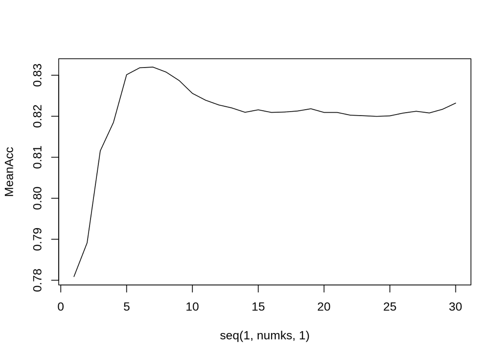

```
##       classifications
##        Ales IPA
##   Ales  173  33
##   IPA    24  82
```

```
##  Accuracy
## 0.8173077
```

```
## Sensitivity
##   0.8781726
```

```
## Specificity
##   0.7130435
```

## Question 9

### Part 1: Style Predictions from IBU and Ounces (KNN)

**With k = 6 and IBU and Ounce variables, below is the accuracy, sensitivity, and specificity**

```
## [1] "Mean Accuracy"
```

```
## [1] 0.8126923
```

```
## [1] "Mean Sensitivity"
```

```
## [1] 0.7501149
```

```
## [1] "Mean Specificity"
```

```
## [1] 0.8557142
```

### Part 2: Style Predictions from ABV and Ounces (KNN)

**With k = 6 and ABV and Ounce variables, below is the accuracy, sensitivity, and specificity.**

```
## [1] "Mean Accuracy"
```

```
## [1] 0.7398167
```

```
## [1] "Mean Sensitivity"
```

```
## [1] 0.6327805
```

```
## [1] "Mean Specificity"
```

```
## [1] 0.7990806
```